# chapter3.Rmd

Leena Huiku

18112018

# Exercise 3. Analysis of the student performance including alcohol consumption

# Introduction

The data of this analysis is from the Portugese survey on student performance in secondary education (high school). The database was built from two sources: school reports and questionnaires, the latter used to complement the previous information. The data was collected during the years 2005-2006. The performance was scrutinized in two distinct subjects: Mathematics and Portuguese language.

The datasets were modelled by P. Cortez and A. Silva, described in the paper “Using Data Mining to Predict Secondary School Student Performance” (2008) http://www3.dsi.uminho.pt/pcortez/student.pdf

## Description of the data

To read the data in.

```r
alc <- as.data.frame(read.table('data/alc.csv',  sep="\t", header=TRUE))
```

All variables of the data can be displayed by using glimpse function.

```r
glimpse(alc)
```

```
## Observations: 382
## Variables: 35
## $ school     <fct> GP, GP, GP, GP, GP, GP, GP, GP, GP, GP, GP, GP, GP,...
## $ sex        <fct> F, F, F, F, F, M, M, F, M, M, F, F, M, M, M, F, F, ...
## $ age        <int> 18, 17, 15, 15, 16, 16, 16, 17, 15, 15, 15, 15, 15,...
## $ address    <fct> U, U, U, U, U, U, U, U, U, U, U, U, U, U, U, U, U, ...
## $ famsize    <fct> GT3, GT3, LE3, GT3, GT3, LE3, LE3, GT3, LE3, GT3, G...
## $ Pstatus    <fct> A, T, T, T, T, T, T, A, A, T, T, T, T, T, A, T, T, ...
## $ Medu       <int> 4, 1, 1, 4, 3, 4, 2, 4, 3, 3, 4, 2, 4, 4, 2, 4, 4, ...
## $ Fedu       <int> 4, 1, 1, 2, 3, 3, 2, 4, 2, 4, 4, 1, 4, 3, 2, 4, 4, ...
## $ Mjob       <fct> at_home, at_home, at_home, health, other, services,...
## $ Fjob       <fct> teacher, other, other, services, other, other, othe...
## $ reason     <fct> course, course, other, home, home, reputation, home...
## $ nursery    <fct> yes, no, yes, yes, yes, yes, yes, yes, yes, yes, ye...
## $ internet   <fct> no, yes, yes, yes, no, yes, yes, no, yes, yes, yes,...
```

[output cut: 22 more lines]

The dataset consists of 35 variables and 382 observations. The variables are of both numerical and character type. There are also binary variables.

The data variables include student grades, demographic, social and school related features. Special attention is paid on the alcoholic consumption and its possible impact on student performance. There are two alcohol consumption variables - daily and weekly use - which are combined and averaged to variable alc_use. The target variable is binary (low/high) variable consumption of alcohol.

## Four interesting variables to explain the alcohol consumption

The purpose of the analysis is to study the relationships between high/low alcohol consumption and some of the other variables in the data. After some experiments, I have chosen four explanatory variables that might be indicators of alcohol consumption.

1. Weekly study time could indicate to alcohol consumption - variable studytime.
2. Students who go out with friends could use more alcohol - variable goout.
3. Number of school absences, which could be an indicator of alcohol consumption - variable absenses.
4. Results in final grade, students with poor results might drink more alcohol - variable G3.

A summary and four plots of the chosen variables are showcased below.

```r
summary(alc[c('studytime', 'goout', 'absences', 'G3')])
```

```
##    studytime         goout          absences          G3
##  Min.   :1.000   Min.   :1.000   Min.   : 0.0   Min.   : 0.00
##  1st Qu.:1.000   1st Qu.:2.000   1st Qu.: 1.0   1st Qu.:10.00
##  Median :2.000   Median :3.000   Median : 3.0   Median :12.00
##  Mean   :2.037   Mean   :3.113   Mean   : 4.5   Mean   :11.46
##  3rd Qu.:2.000   3rd Qu.:4.000   3rd Qu.: 6.0   3rd Qu.:14.00
##  Max.   :4.000   Max.   :5.000   Max.   :45.0   Max.   :18.00
```

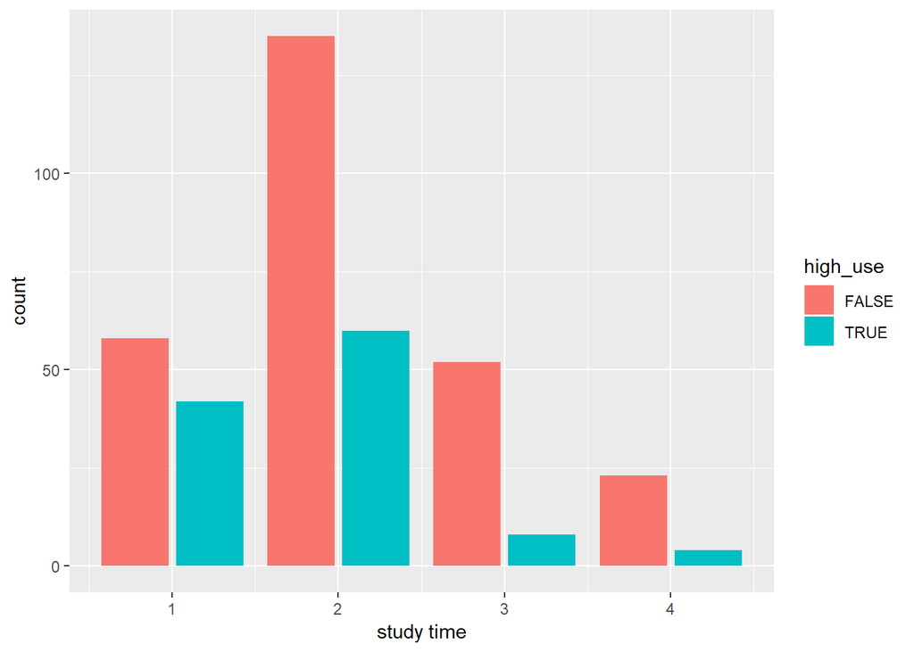

```r
v1 <- ggplot(data = alc, aes(studytime))
v1 + geom_bar(aes(fill = high_use), stat="count", position = "dodge2") + xlab('study time')
```

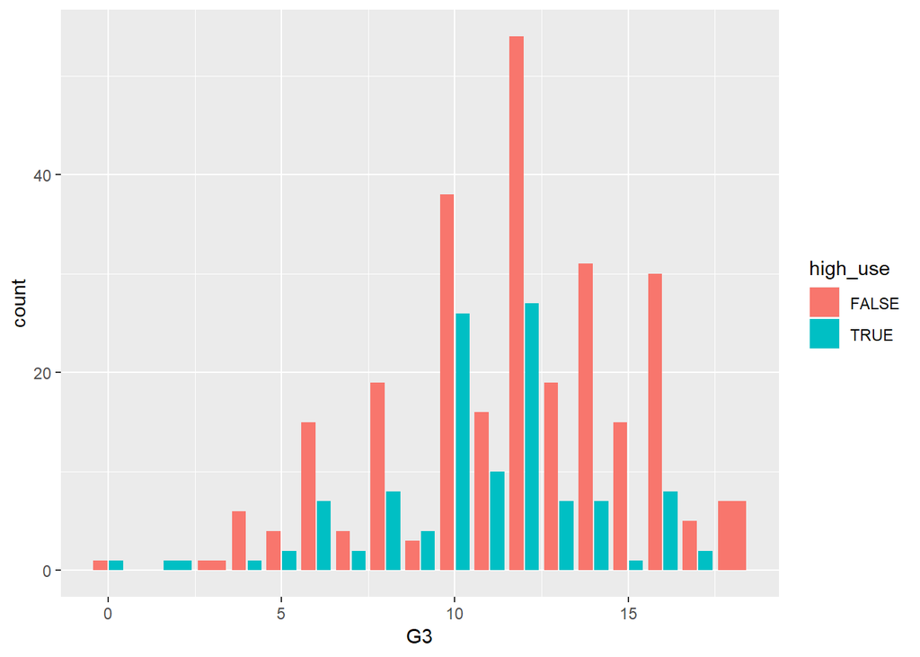

```r
v2 <- ggplot(data = alc, aes(G3))
v2 + geom_bar(aes(fill = high_use), stat="count", position = "dodge2") + xlab('G3')
```

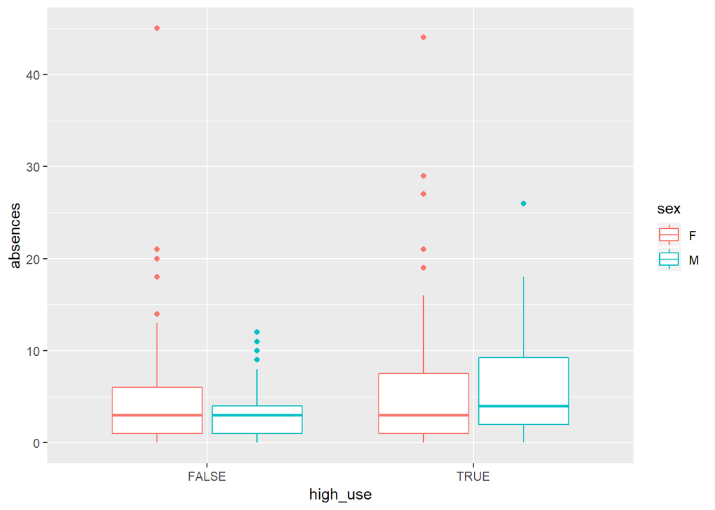

```r
v3 <- ggplot(data = alc, aes(x = high_use, y=absences, col = sex))
v3 + geom_boxplot() + xlab("high_use")
```

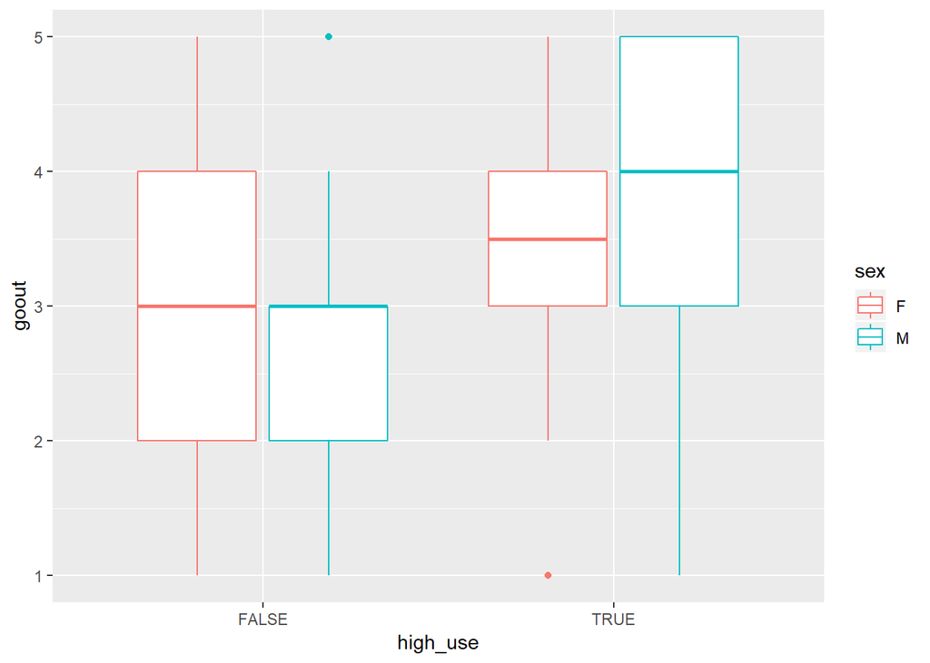

```r
v4 <- ggplot(data = alc, aes(x = high_use, y=goout, col = sex))
v4 + geom_boxplot() + xlab("high_use")
```

# Logistic regression analysis

Based on the summary and graphics above, the four assumptioms stated earlier seemed to be eligible at least to some extent. The next step is to use logistic regression to statistically explore the relationship between my chosen explanatory variables and the binary high/low alcohol consumption variable as the target variable.

A summary of the fitted model is presented and interpreted.

```r
m <- glm(high_use ~  + studytime + goout + absences + G3, data = alc, family = "binomial")
summary(m)
```

```
##
## Call:
## glm(formula = high_use ~ +studytime + goout + absences + G3,
##     family = "binomial", data = alc)
##
## Deviance Residuals:
##     Min       1Q   Median       3Q      Max
## -1.8717  -0.7686  -0.5171   0.8345   2.4941
##
## Coefficients:
##             Estimate Std. Error z value Pr(>|z|)
## (Intercept) -2.15991    0.69106  -3.125  0.00178 **
## studytime   -0.54223    0.16834  -3.221  0.00128 **
## goout        0.71610    0.11855   6.040 1.54e-09 ***
## absences     0.06912    0.02205   3.135  0.00172 **
## G3          -0.02831    0.03925  -0.721  0.47074
## ---
## Signif. codes:  0 '***' 0.001 '**' 0.01 '*' 0.05 '.' 0.1 ' ' 1
##
## (Dispersion parameter for binomial family taken to be 1)
##
##     Null deviance: 465.68  on 381  degrees of freedom
## Residual deviance: 389.62  on 377  degrees of freedom
## AIC: 399.62
##
## Number of Fisher Scoring iterations: 4
```

The summary of the fitted model showcases that there is relatively strong relationship between alcohol consumption and other variables except G3 final grade results. The study time, going out with friends and the number of school absences explain the alcohol consumption rather well and the results are statistically significant.

The next step is to present and interpret the coefficients of the model as odds ratios.

```r
OR <- exp(coef(m))
OR
```

```
## (Intercept)   studytime       goout    absences          G3
##   0.1153350   0.5814504   2.0464293   1.0715608   0.9720874
```

Odds ratio can be used to quantify the relationship between variables. The exponents of the coefficients can be interpreted as odds ratios between a unit change (vs no change) in the corresponding explanatory variable.

Confidence intervals are provided for odds ratios.

```r
CI <-exp(confint(m))
cbind(OR, CI)
```

```
##                    OR      2.5 %    97.5 %
## (Intercept) 0.1153350 0.02867633 0.4342130
## studytime   0.5814504 0.41353969 0.8016563
## goout       2.0464293 1.63144106 2.5994233
## absences    1.0715608 1.02739900 1.1214957
## G3          0.9720874 0.90012478 1.0503315
```

The results above showcase that the confidence intervals of the odds rations imply the same conclusion that the final frade G3 hypothesis was wrong. The new fitted model is created and calculated by removing variable G3. A new summary and recalcutions of the odds rations (OR) and the confidental intervals (CI) are carried out.

```r
m <- glm(high_use ~ studytime + goout + absences, data = alc, family = "binomial")
summary(m)
```

```
##
## Call:
## glm(formula = high_use ~ studytime + goout + absences, family = "binomial",
##     data = alc)
##
## Deviance Residuals:
##     Min       1Q   Median       3Q      Max
## -1.8457  -0.7733  -0.5178   0.8432   2.5036
##
## Coefficients:
##             Estimate Std. Error z value Pr(>|z|)
## (Intercept) -2.48582    0.52982  -4.692 2.71e-06 ***
## studytime   -0.56048    0.16672  -3.362 0.000774 ***
## goout        0.72735    0.11786   6.171 6.78e-10 ***
## absences     0.07011    0.02204   3.181 0.001470 **
## ---
## Signif. codes:  0 '***' 0.001 '**' 0.01 '*' 0.05 '.' 0.1 ' ' 1
##
## (Dispersion parameter for binomial family taken to be 1)
##
##     Null deviance: 465.68  on 381  degrees of freedom
## Residual deviance: 390.14  on 378  degrees of freedom
## AIC: 398.14
##
## Number of Fisher Scoring iterations: 4
```

```r
cbind(exp(coef(m)), exp(confint(m)))
```

```
##                             2.5 %    97.5 %
## (Intercept) 0.08325721 0.02864231 0.2297441
## studytime   0.57093348 0.40733791 0.7846264
## goout       2.06958310 1.65203749 2.6250666
## absences    1.07262851 1.02840235 1.1225709
```

The statistics above showcase that the recalculated new model contains explanatory variables that are statistically significant. The confidence intervals show that the model can be used for predictions.

# Prediction of the model

According to the logistic regression model above, it is possible to explore the predictive power of the model.

The next steps are required:

```r
# Predict the probability of high_use
probabilities <- predict(m, type = "response")

# Add the predicted probabilities to 'alc'
alc <- mutate(alc, probability = probabilities)

# Use the probabilities to make a prediction of high_use
alc <- mutate(alc, prediction = probability > 0.5)

# Tabulate the target variable versus the predictions
tbl <- table(high_use = alc$high_use, prediction = alc$prediction)
addmargins(tbl)
```

```
##         prediction
## high_use FALSE TRUE Sum
##    FALSE   246   22 268
##    TRUE     66   48 114
##    Sum     312   70 382
```

```r
round(addmargins(prop.table(tbl)), 2)
```

```
##         prediction
## high_use FALSE TRUE  Sum
##    FALSE  0.64 0.06 0.70
##    TRUE   0.17 0.13 0.30
##    Sum    0.82 0.18 1.00
```

The statistics above show that the model predicts less occurences of high use than the survey data contain. The percentage of students who use a lot of alcohol is 30% based on the survey data. The model predicts that the percentage is 18%. This can be shown by graphics:

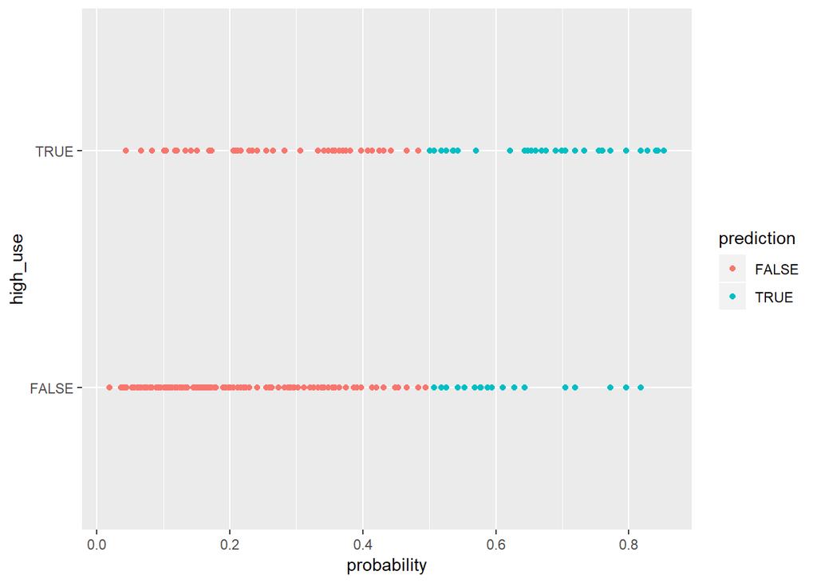

```r
g = ggplot(alc, aes(x = probability, y = high_use, col=prediction))
g+geom_point()
```

## Computation the total proportion of inaccurately classified individuals (= the training error)

The logistic regression aim to (approximately) minimize the incorrectly classified observations. Since we know how to make predictions with our model, we can also compute the average number of incorrect predictions. First define a loss function (mean prediction error).

```r
loss_func = function(class, prob) {
  n_wrong = abs(class - prob) > 0.5
  mean(n_wrong)
}
# Call loss_func to compute the average number of wrong predictions in the (training) data
loss_func(class = alc$high_use, prob = alc$probability)
```

```
## [1] 0.2303665
```

The training error is 23%, which implies that the accuracy of the model is a little over 76%. The accuracy is not very high, but as we have seen, my choice of the explanatory variables didn’t succeed perfectly as well. All explanatory variables were not statistically significant so by the guessing strategy the results were not better.

# Cross-validation (bonus task)

Cross-validation is a method of testing a predictive model on unseen data. In cross-validation, the value of a penalty (loss) function (mean prediction error) is computed on data not used for finding the model. Low value = good. Cross-validation gives a good estimate of the actual predictive power of the model.

I perform 10-fold cross-validation on my model.

```r
# 10-fold cross-validation
cv <- cv.glm(data = alc, cost = loss_func, glmfit = m, K = 10)

# Print the average number of wrong predictions in the cross validation
cv$delta[1]
```

```
## [1] 0.2408377
```

The average number of wrong predictions of my model = 0.2408377, which is better than in the IODS course’s DataCamp exercises = 0.2591623.

To improve the model it is possible to add explanatory variables into the model and recalculate the cross-validation. Based on the DataCamp material there are two variables that could be added to my model: failures and sex. I will add the sex variable as an explanatory variable, because it correlates strongly with the target variable according to DataCamp calculations.

```r
m_2 <- glm(high_use ~ studytime + goout + absences + sex, data = alc, family = "binomial")
# Summary of the model
summary(m_2)
```

```
##
## Call:
## glm(formula = high_use ~ studytime + goout + absences + sex,
##     family = "binomial", data = alc)
##
## Deviance Residuals:
##     Min       1Q   Median       3Q      Max
## -1.9103  -0.7892  -0.5021   0.7574   2.6021
##
## Coefficients:
##             Estimate Std. Error z value Pr(>|z|)
## (Intercept) -3.20483    0.59429  -5.393 6.94e-08 ***
## studytime   -0.42116    0.17058  -2.469 0.013551 *
## goout        0.72677    0.11994   6.059 1.37e-09 ***
## absences     0.07811    0.02244   3.481 0.000499 ***
## sexM         0.78173    0.26555   2.944 0.003242 **
## ---
## Signif. codes:  0 '***' 0.001 '**' 0.01 '*' 0.05 '.' 0.1 ' ' 1
##
## (Dispersion parameter for binomial family taken to be 1)
##
##     Null deviance: 465.68  on 381  degrees of freedom
## Residual deviance: 381.31  on 377  degrees of freedom
## AIC: 391.31
##
## Number of Fisher Scoring iterations: 4
```

```r
#Calculations of the odds of ratios and the confidence interval
cbind(exp(coef(m_2)), exp(confint(m_2)))
```

```
##                             2.5 %    97.5 %
## (Intercept) 0.04056573 0.01222314 0.1263579
## studytime   0.65628388 0.46510383 0.9099505
## goout       2.06838526 1.64470314 2.6349716
## absences    1.08123884 1.03577383 1.1324143
## sexM        2.18525582 1.30370562 3.7010763
```

```r
# Prediction of the probability
probabilities_2 <- predict(m_2, type = "response")
# Probabilities to alc
alc <- mutate(alc, probability_2 = probabilities_2)
# Calculate a logical high use value based on probabilities.
alc <- mutate(alc, prediction_2 = probability_2 > 0.5)
# Recalculation of cross-validation and print the average number of wrong predictions.
cv_2 <- cv.glm(data = alc, cost = loss_func, glmfit = m_2, K = 10)
cv_2$delta[1]
```

```
## [1] 0.2120419
```

The average number of wrong predictions of the recalculated model = 0.2120419, which is much better than the correspondent figure in the original model.